# Project 3

Jared Lyon

4/22/2022

# Problem 1

```r
# read in data
benguela <- read.csv("http://faraway.neu.edu/biostats/assn3_benguela.csv")
california <- read.csv("http://faraway.neu.edu/biostats/assn3_california.csv")
canary <- read.csv("http://faraway.neu.edu/biostats/assn3_canary.csv")
humboldt <- read.csv("http://faraway.neu.edu/biostats/assn3_humboldt.csv")
str(benguela)
```

```
## 'data.frame':    150 obs. of  23 variables:
##  $ model1 : num  0.648 0.722 0.685 0.878 0.693 ...
##  $ model2 : num  0.847 0.886 0.922 0.873 0.9 ...
##  $ model3 : num  0.313 0.705 0.669 0.645 0.394 ...
##  $ model4 : num  0.576 0.607 0.591 0.595 0.649 ...
##  $ model5 : num  0.821 0.862 0.925 0.862 0.785 ...
##  $ model6 : num  1.006 1.071 1.034 0.795 1.083 ...
##  $ model7 : num  0.962 0.815 0.706 0.757 0.872 ...
##  $ model8 : num  1.4 1.34 1.29 1.28 1.37 ...
##  $ model9 : num  1.078 1.003 0.845 0.988 1.046 ...
##  $ model10: num  0.973 0.856 0.709 0.75 0.986 ...
##  $ model11: num  0.739 0.661 0.953 1.002 0.815 ...
##  $ model12: num  0.667 0.633 0.87 0.71 0.552 ...
##  $ model13: num  0.481 0.691 0.643 0.616 0.757 ...
##  $ model14: num  0.32 0.215 0.344 0.465 0.685 ...
##  $ model15: num  0.803 0.773 0.647 0.982 0.677 ...
##  $ model16: num  0.564 0.285 0.165 0.532 0.437 ...
##  $ model17: num  0.416 0.468 0.656 0.493 0.472 ...
##  $ model18: num  0.466 0.636 0.236 0.303 0.503 ...
##  $ model19: num  1.52 1.53 1.69 1.68 1.84 ...
##  $ model20: num  0.805 0.84 0.999 0.676 0.889 ...
##  $ model21: num  0.852 1.017 0.926 1.029 0.919 ...
##  $ model22: num  1.09 1.04 0.8 1.18 1.15 ...
##  $ year   : int  1950 1951 1952 1953 1954 1955 1956 1957 1958 1959 ...
```

```r
str(california)
```

```
## 'data.frame':    150 obs. of  23 variables:
##  $ model1 : num  0.348 0.33 0.385 0.501 0.43 ...
##  $ model2 : num  0.321 0.325 0.37 0.304 0.351 ...
##  $ model3 : num  0.431 0.242 0.33 0.39 0.311 ...
##  $ model4 : num  0.12 0.195 0.223 0.183 0.215 ...
##  $ model5 : num  0.198 0.168 0.213 0.309 0.243 ...
##  $ model6 : num  0.274 0.361 0.423 0.334 0.339 ...
##  $ model7 : num  0.685 0.539 0.701 0.765 0.521 ...
##  $ model8 : num  0.575 0.592 0.59 0.516 0.482 ...
##  $ model9 : num  0.463 0.333 0.402 0.346 0.5 ...
##  $ model10: num  0.33 0.402 0.35 0.427 0.392 ...
##  $ model11: num  0.312 0.328 0.285 0.25 0.323 ...
##  $ model12: num  0.324 0.449 0.401 0.289 0.367 ...
##  $ model13: num  0.578 0.425 0.492 0.313 0.507 ...
##  $ model14: num  0.165 0.15 0.123 0.16 0.21 ...
##  $ model15: num  0.24 0.172 0.24 0.182 0.169 ...
##  $ model16: num  0.1439 0.1459 0.0937 0.1573 0.0236 ...
##  $ model17: num  0.202 0.166 0.29 0.25 0.222 ...
##  $ model18: num  0.18 0.321 0.268 0.211 0.276 ...
##  $ model19: num  0.546 0.339 0.419 0.668 0.512 ...
##  $ model20: num  0.369 0.435 0.353 0.403 0.398 ...
##  $ model21: num  0.421 0.323 0.344 0.309 0.423 ...
##  $ model22: num  0.294 0.281 0.338 0.21 0.396 ...
##  $ year   : int  1950 1951 1952 1953 1954 1955 1956 1957 1958 1959 ...
```

```r
str(canary)
```

```
## 'data.frame':    150 obs. of  23 variables:
##  $ model1 : num  0.411 0.183 0.39 0.311 0.401 ...
##  $ model2 : num  0.349 0.486 0.487 0.386 0.473 ...
##  $ model3 : num  0.328 0.372 0.264 0.299 0.26 ...
##  $ model4 : num  0.393 0.381 0.395 0.382 0.463 ...
##  $ model5 : num  0.328 0.522 0.262 0.432 0.329 ...
##  $ model6 : num  0.518 0.52 0.625 0.732 0.607 ...
##  $ model7 : num  0.915 0.868 0.882 0.751 0.865 ...
##  $ model8 : num  0.843 0.814 1.078 0.878 0.794 ...
##  $ model9 : num  0.49 0.557 0.334 0.266 0.683 ...
##  $ model10: num  0.315 0.564 0.301 0.293 0.272 ...
##  $ model11: num  0.45 0.19 0.418 0.404 0.438 ...
##  $ model12: num  0.556 0.462 0.559 0.467 0.506 ...
##  $ model13: num  0.381 0.469 0.352 0.553 0.491 ...
##  $ model14: num  0.478 0.471 0.36 0.403 0.465 ...
##  $ model15: num  0.576 0.606 0.642 0.586 0.493 ...
##  $ model16: num  0.391 0.327 0.311 0.388 0.211 ...
##  $ model17: num  0.253 0.183 0.429 0.263 0.386 ...
##  $ model18: num  0.38 0.295 0.285 0.291 0.346 ...
##  $ model19: num  0.81 0.953 0.666 1.026 0.951 ...
##  $ model20: num  0.472 0.577 0.491 0.529 0.438 ...
##  $ model21: num  0.41 0.549 0.272 0.345 0.308 ...
##  $ model22: num  0.367 0.556 0.696 0.354 0.454 ...
##  $ year   : int  1950 1951 1952 1953 1954 1955 1956 1957 1958 1959 ...
```

```r
str(humboldt)
```

```
## 'data.frame':    150 obs. of  23 variables:
##  $ model1 : num  0.33 0.169 0.224 0.139 0.273 ...
##  $ model2 : num  0.233 0.487 0.394 0.381 0.444 ...
##  $ model3 : num  0.155 0.075 0.162 0.286 0.092 ...
##  $ model4 : num  0.152 0.135 0.365 0.138 0.189 ...
##  $ model5 : num  0.354 0.502 0.358 0.418 0.436 ...
##  $ model6 : num  0.733 0.635 0.639 0.465 0.561 ...
##  $ model7 : num  0.482 0.405 0.461 0.492 0.415 ...
##  $ model8 : num  0.575 0.694 0.391 0.551 0.54 ...
##  $ model9 : num  0.332 0.48 0.393 0.556 0.552 ...
##  $ model10: num  0.301 0.241 0.36 0.241 0.277 ...
##  $ model11: num  0.131 0.196 0.261 0.245 0.151 ...
##  $ model12: num  0.382 0.127 0.285 0.31 0.309 ...
##  $ model13: num  0.458 0.366 0.286 0.244 0.499 ...
##  $ model14: num  0.154 0.294 0.122 0.252 0.375 ...
##  $ model15: num  0.32 0.42 0.139 0.528 0.367 ...
##  $ model16: num  0.3839 0.1857 0.253 0.1785 0.0113 ...
##  $ model17: num  0.0632 0.01768 0.02982 -0.10373 -0.00712 ...
##  $ model18: num  0.0354 0.1135 -0.049 -0.0303 0.0386 ...
##  $ model19: num  0.715 0.71 1.094 0.739 0.679 ...
##  $ model20: num  0.667 0.56 0.741 0.37 0.516 ...
##  $ model21: num  0.343 0.643 0.38 0.557 0.376 ...
##  $ model22: num  0.0171 0.4296 0.3321 0.5203 0.4056 ...
##  $ year   : int  1950 1951 1952 1953 1954 1955 1956 1957 1958 1959 ...
```

## 1.

```r
# add before/after column
california$period <- ifelse(california$year < 2025 , "before", "after")
benguela$period <- ifelse(benguela$year < 2025, "before", "after")
canary$period <- ifelse(canary$year < 2025, "before", "after")
humboldt$period <- ifelse(humboldt$year < 2025, "before", "after")
```

## 2.

```r
# Multimodel mean for California
california.mean <- data.frame(year = california$year, period = california$period,
upwelling = rowMeans(california[1:22]))
# Multimodel mean for Canary
canary.mean <- data.frame(year = canary$year, period = canary$period,
upwelling = rowMeans(canary[1:22]))
# Multimodel mean for Humboldt
humboldt.mean <- data.frame(year = humboldt$year, period = humboldt$period,
upwelling = rowMeans(humboldt[1:22]))
# Multimodel mean for Benguela
benguela.mean <- data.frame(year = benguela$year, period = benguela$period,
upwelling = rowMeans(benguela[1:22]))

california.mean
```

```
##     year period upwelling
## 1   1950 before 0.3417591
## 2   1951 before 0.3191518
## 3   1952 before 0.3469232
## 4   1953 before 0.3398432
## 5   1954 before 0.3459844
## 6   1955 before 0.3287795
## 7   1956 before 0.3334814
## 8   1957 before 0.3150314
## 9   1958 before 0.3490642
## 10  1959 before 0.3629041
## 11  1960 before 0.3254918
## 12  1961 before 0.3289655
## 13  1962 before 0.3401118
## 14  1963 before 0.3494630
```

[output cut: 136 more lines]

```r
canary.mean
```

```
##     year period upwelling
## 1   1950 before 0.4734609
## 2   1951 before 0.4957750
## 3   1952 before 0.4772050
## 4   1953 before 0.4699382
## 5   1954 before 0.4834586
## 6   1955 before 0.4718141
## 7   1956 before 0.4411505
## 8   1957 before 0.4348432
## 9   1958 before 0.4798291
## 10  1959 before 0.4871809
## 11  1960 before 0.4535823
## 12  1961 before 0.4041905
## 13  1962 before 0.4766877
## 14  1963 before 0.4677618
```

[output cut: 136 more lines]

```r
humboldt.mean
```

```
##     year period upwelling
## 1   1950 before 0.3325485
## 2   1951 before 0.3584342
## 3   1952 before 0.3464716
## 4   1953 before 0.3398514
## 5   1954 before 0.3408307
## 6   1955 before 0.3033469
## 7   1956 before 0.3268234
## 8   1957 before 0.3482359
## 9   1958 before 0.3040523
## 10  1959 before 0.2663468
## 11  1960 before 0.3474631
## 12  1961 before 0.3442102
## 13  1962 before 0.2799914
## 14  1963 before 0.3610498
```

[output cut: 136 more lines]

```r
benguela.mean
```

```
##     year period upwelling
## 1   1950 before 0.7887173
## 2   1951 before 0.8022314
## 3   1952 before 0.7869314
## 4   1953 before 0.8226568
## 5   1954 before 0.8397959
## 6   1955 before 0.7614782
## 7   1956 before 0.7775859
## 8   1957 before 0.7519577
## 9   1958 before 0.7905705
## 10  1959 before 0.8251614
## 11  1960 before 0.8032082
## 12  1961 before 0.7958373
## 13  1962 before 0.7862427
## 14  1963 before 0.8052882
```

[output cut: 136 more lines]

## 3.

In order to test for normality, a Shapiro-Wilk test will be applied to the datapoints of each set. Eight tests total are needed, since each of the four datasets has two periods. In all eight tests, the hypotheses are: H0: The sample population is normally distributed. HA: The sample population is not normally distributed.

```r
# shapiro test for before periods
shapiro.test(as.matrix(subset(california.mean, period == "before", select = upwelling)))
```

```
##
##  Shapiro-Wilk normality test
##
## data:  as.matrix(subset(california.mean, period == "before", select = upwelling))
## W = 0.98943, p-value = 0.7929
```

```r
shapiro.test(as.matrix(subset(canary.mean, period == "before", select = upwelling)))
```

```
##
##  Shapiro-Wilk normality test
##
## data:  as.matrix(subset(canary.mean, period == "before", select = upwelling))
## W = 0.98603, p-value = 0.5817
```

```r
shapiro.test(as.matrix(subset(humboldt.mean, period == "before", select = upwelling)))
```

```
##
##  Shapiro-Wilk normality test
##
## data:  as.matrix(subset(humboldt.mean, period == "before", select = upwelling))
## W = 0.9877, p-value = 0.6858
```

```r
shapiro.test(as.matrix(subset(benguela.mean, period == "before", select = upwelling)))
```

```
##
##  Shapiro-Wilk normality test
##
## data:  as.matrix(subset(benguela.mean, period == "before", select = upwelling))
## W = 0.98281, p-value = 0.4028
```

```r
# shapiro test for after periods
shapiro.test(as.matrix(subset(california.mean, period == "after", select = upwelling)))
```

```
##
##  Shapiro-Wilk normality test
##
## data:  as.matrix(subset(california.mean, period == "after", select = upwelling))
## W = 0.97638, p-value = 0.1737
```

```r
shapiro.test(as.matrix(subset(canary.mean, period == "after", select = upwelling)))
```

```
##
##  Shapiro-Wilk normality test
##
## data:  as.matrix(subset(canary.mean, period == "after", select = upwelling))
## W = 0.96229, p-value = 0.02496
```

```r
shapiro.test(as.matrix(subset(humboldt.mean, period == "after", select = upwelling)))
```

```
##
##  Shapiro-Wilk normality test
##
## data:  as.matrix(subset(humboldt.mean, period == "after", select = upwelling))
## W = 0.96227, p-value = 0.02489
```

```r
shapiro.test(as.matrix(subset(benguela.mean, period == "after", select = upwelling)))
```

```
##
##  Shapiro-Wilk normality test
##
## data:  as.matrix(subset(benguela.mean, period == "after", select = upwelling))
## W = 0.98991, p-value = 0.8204
```

The p-values for all ‘before’ periods within the California, Benguela, Canary, and Humboldt models are >0.05, meaning the null hypothesis can be accepted and that these datasets are normally distributed. However, the p-values for the ‘after’ datasets for Canary and Humboldt are <0.05, meaning that we can reject the null hypothesis for these two sets and that they are not normally distributed. Lastly, the p-values of the ‘after’ datasets for California and Benguela are >0.05, thus we can accept the null hypothesis for these groups and assert that they are normally distributed.

Because two of our eight tests showed an absence of normality, this means we must resort to non-parametric tests. Although non-parametric tests can be applied to more situations than their parametric counterparts since they do not rely on any distribution types, they have less statistical power due to a lack of assumptions that they make about the data.

## 4.

Since we must resort to non-parametric tests, a Mann-Whitney-Wilcox Test is the most applicable in order to compare the group means between each demographics ‘before’ and ‘after’ subsets. On the other hand, a t-test is rejected since the t-test assumes normality and is thus a parametric test. The test hypotheses are: H0: The sample means are equal. HA: The sample means are not equal.

```r
#conduct wilcox test on each of the four pairs
# Canary
model.upwelling.canary <- wilcox.test(as.matrix(subset(canary.mean,
period == "before", select = upwelling)), as.matrix(subset(canary.mean,
period == "after", select = upwelling)))
model.upwelling.canary
```

```
##
##  Wilcoxon rank sum test with continuity correction
##
## data:  as.matrix(subset(canary.mean, period == "before", select = upwelling)) and as.matrix(subset(canary.mean, period == "after", select = upwelling))
## W = 162, p-value < 2.2e-16
## alternative hypothesis: true location shift is not equal to 0
```

```r
# California
model.upwelling.california <- wilcox.test(as.matrix(subset(california.mean,
period == "before", select = upwelling)), as.matrix(subset(california.mean,
period == "after", select = upwelling)))
model.upwelling.california
```

```
##
##  Wilcoxon rank sum test with continuity correction
##
## data:  as.matrix(subset(california.mean, period == "before", select = upwelling)) and as.matrix(subset(california.mean, period == "after", select = upwelling))
## W = 1731, p-value = 4.841e-05
## alternative hypothesis: true location shift is not equal to 0
```

```r
# Humboldt
model.upwelling.humboldt <- wilcox.test(as.matrix(subset(humboldt.mean,
period == "before", select = upwelling)), as.matrix(subset(humboldt.mean,
period == "after", select = upwelling)))
model.upwelling.humboldt
```

```
##
##  Wilcoxon rank sum test with continuity correction
##
## data:  as.matrix(subset(humboldt.mean, period == "before", select = upwelling)) and as.matrix(subset(humboldt.mean, period == "after", select = upwelling))
## W = 276, p-value < 2.2e-16
## alternative hypothesis: true location shift is not equal to 0
```

```r
# Benguela
model.upwelling.benguela <- wilcox.test(as.matrix(subset(benguela.mean,
period == "before", select = upwelling)), as.matrix(subset(benguela.mean,
period == "after", select = upwelling)))
model.upwelling.benguela
```

```
##
##  Wilcoxon rank sum test with continuity correction
##
## data:  as.matrix(subset(benguela.mean, period == "before", select = upwelling)) and as.matrix(subset(benguela.mean, period == "after", select = upwelling))
## W = 306, p-value < 2.2e-16
## alternative hypothesis: true location shift is not equal to 0
```

The results of all four tests result in p-values lower than 0.05, meaning we can reject the null hypothesis and assert that none of the ‘before’ vs. ‘after’ demographic pairs have equal means.

## 5.

```r
# Compute group means and stderrs for California
mean.upwelling.california <- aggregate(upwelling ~ period, FUN = mean,
data = california.mean)
sderr.upwelling.california <- aggregate(upwelling ~ period, FUN = function(x) sd(x)/sqrt(length(x)),
data = california.mean)

# Compute group means and stderrs for Canary
mean.upwelling.canary <- aggregate(upwelling ~ period, FUN = mean, data = canary.mean)
sderr.upwelling.canary <- aggregate(upwelling ~ period, FUN = function(x) sd(x)/sqrt(length(x)),
data = canary.mean)

# Compute group means and stderrs for Humboldt
mean.upwelling.humboldt <- aggregate(upwelling ~ period, FUN = mean,
data = humboldt.mean)
sderr.upwelling.humboldt <- aggregate(upwelling ~ period, FUN = function(x) sd(x)/sqrt(length(x)),
data = humboldt.mean)

# Compute group means and stderrs for Benguela
mean.upwelling.benguela <- aggregate(upwelling ~ period, FUN = mean,
data = benguela.mean)
sderr.upwelling.benguela <- aggregate(upwelling ~ period, FUN = function(x) sd(x)/sqrt(length(x)),
data = benguela.mean)
```

## 6.

```r
# Combine data into a single means dataframe
upwelling.mean <- data.frame(region = c("Canary", "California",
"Benguela", "Humboldt"), after = c(mean.upwelling.canary$upwelling[2],
mean.upwelling.california$upwelling[2], mean.upwelling.benguela$upwelling[2],
mean.upwelling.humboldt$upwelling[2]), before = c(mean.upwelling.canary$upwelling[1],
mean.upwelling.california$upwelling[1], mean.upwelling.benguela$upwelling[1],
mean.upwelling.humboldt$upwelling[1]))
upwelling.mean
```

```
##       region     after    before
## 1     Canary 0.4721527 0.5670722
## 2 California 0.3415715 0.3515175
## 3   Benguela 0.8206088 0.9159404
## 4   Humboldt 0.3717131 0.4732848
```

```r
# Combine data into a single stderrs dataframe
upwelling.sderr <- data.frame(region = c("Canary", "California",
"Benguela", "Humboldt"), after = c(sderr.upwelling.canary$upwelling[2],
sderr.upwelling.california$upwelling[2], sderr.upwelling.benguela$upwelling[2],
sderr.upwelling.humboldt$upwelling[2]), before = c(sderr.upwelling.canary$upwelling[1],
sderr.upwelling.california$upwelling[1], sderr.upwelling.benguela$upwelling[1],
sderr.upwelling.humboldt$upwelling[1]))
upwelling.sderr
```

```
##       region       after      before
## 1     Canary 0.003312932 0.004403856
## 2 California 0.001850690 0.001478153
## 3   Benguela 0.004914237 0.004653388
## 4   Humboldt 0.004651444 0.005573818
```

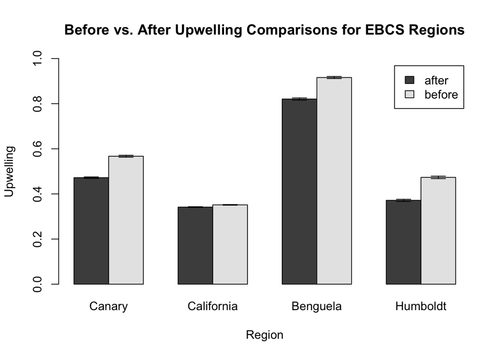

```r
## plot the results
bp <- barplot(t(as.matrix(upwelling.mean[, 2:3])), beside = TRUE, ylim = c(0, 1), xlab = "Region", names = upwelling.mean$region, ylab = "Upwelling", main = "Before vs. After Upwelling Comparisons for EBCS Regions", legend = TRUE)
arrows(x0 = bp, y0 = t(as.matrix(upwelling.mean[, 2:3])) - t(as.matrix(upwelling.sderr[, 2:3])), y1 = t(as.matrix(upwelling.mean[, 2:3])) + t(as.matrix(upwelling.sderr[, 2:3])), code = 3, angle = 90, length = 0.1)
```

```r
legend
```

[output not shown]

[output not shown]

## 7.

# Problem 2

## 1.

The first possible test to compare sample variances is the parametric F-test, which assumes independent observations and normal distributions. The second possible test is the parametric Levene Test, which also compares sample variances; this test also assumes independent observations, but can be applied to quasi-normal distributions.

## 2.

Given that four tests will be conducted in order to compare the variances between two groups (‘before’ vs. ‘after’), the most applicable test to examine the variances of the groups is the Levene Test since not all of our groups are normally distributed. The hypotheses for this test are as follows: H0: The variances of the groups are equal. HA: The variances of the groups are not equal.

```r
# install levene test
library(car)
```

```r
# conduct Levenetest on each of the four pairs
# Canary
var.upwelling.canary <- leveneTest(upwelling ~ period, canary.mean)
var.upwelling.canary
```

```
## Levene's Test for Homogeneity of Variance (center = median)
##        Df F value  Pr(>F)
## group   1  6.6044 0.01116 *
##       148
## ---
## Signif. codes:  0 '***' 0.001 '**' 0.01 '*' 0.05 '.' 0.1 ' ' 1
```

```r
# California
var.upwelling.california <- leveneTest(upwelling ~ period, california.mean)
var.upwelling.california
```

```
## Levene's Test for Homogeneity of Variance (center = median)
##        Df F value  Pr(>F)
## group   1  5.7206 0.01802 *
##       148
## ---
## Signif. codes:  0 '***' 0.001 '**' 0.01 '*' 0.05 '.' 0.1 ' ' 1
```

```r
# Humboldt
var.upwelling.humboldt <- leveneTest(upwelling ~ period, humboldt.mean)
var.upwelling.humboldt
```

```
## Levene's Test for Homogeneity of Variance (center = median)
##        Df F value  Pr(>F)
## group   1  5.3757 0.02179 *
##       148
## ---
## Signif. codes:  0 '***' 0.001 '**' 0.01 '*' 0.05 '.' 0.1 ' ' 1
```

```r
# Benguela
var.upwelling.benguela <- leveneTest(upwelling ~ period, benguela.mean)
var.upwelling.benguela
```

```
## Levene's Test for Homogeneity of Variance (center = median)
##        Df F value Pr(>F)
## group   1  0.5294  0.468
##       148
```

## 3.

```r
# Compute variance for California
var.upwelling.california <- aggregate(upwelling ~ period, FUN = var,
  data = california.mean)
# Compute variance for Canary
var.upwelling.canary <- aggregate(upwelling ~ period, FUN = var,
  data = canary.mean)
# Compute variance for Humboldt
var.upwelling.humboldt <- aggregate(upwelling ~ period, FUN = var,
  data = humboldt.mean)
# Compute variance for Benguela
var.upwelling.benguela <- aggregate(upwelling ~ period, FUN = var,
  data = benguela.mean)
# Combine data
var.upwelling <- data.frame(region = c("Canary", "California",
  "Benguela", "Humboldt"), after = c(var.upwelling.canary$upwelling[2],
  var.upwelling.california$upwelling[2], var.upwelling.benguela$upwelling[2],
  var.upwelling.humboldt$upwelling[2]), before = c(var.upwelling.canary$upwelling[1],
  var.upwelling.california$upwelling[1], var.upwelling.benguela$upwelling[1],
  var.upwelling.humboldt$upwelling[1]))
var.upwelling
```

```
##       region       after       before
## 1     Canary 0.000823164 0.0014545463
## 2 California 0.000256879 0.0001638703
## 3   Benguela 0.001811230 0.0016240514
## 4   Humboldt 0.001622695 0.0023300588
```

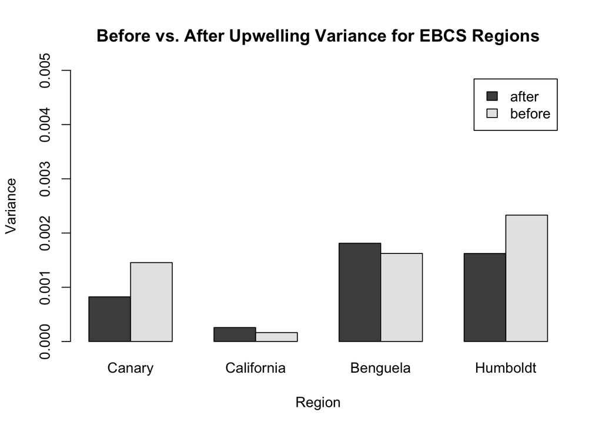

```r
# plot the results
bp <- barplot(t(as.matrix(var.upwelling[, 2:3])), beside = TRUE, ylim = c(0, 0.005), xlab = "Region", names = var.upwelling$region, ylab = "Variance", main = "Before vs. After Upwelling Variance for EBCS Regions", legend = TRUE)
```

## 4.

# Problem 3

## 1.

Since each EBCS will be examined individually, our explanatory variable is time (year) and the response variable is upwelling. Due to the singular nature of both variables, an analysis utilizing simple linear regression may be applied.

## 2.

The assumptions of the test are that the variables are linearly related, the residuals are independent, the residuals have identical homoscedacities, and that the residuals are normally distributed. All of the assumptions are met with the exception of normality specifically within Canary and Humboldt, wherein we know that the ‘after’ period does not contain normally distributed data; thus, we cannot extrapolate such that the residuals in these data sets will be normally distributed. H0: There is no relationship between upwelling and year. HA: There is a relationship between upwelling and year.

```r
# run simple regression tests on each region
benguela.lm = lm(upwelling ~ year, benguela.mean)
summary(benguela.lm)
```

```
##
## Call:
## lm(formula = upwelling ~ year, data = benguela.mean)
##
## Residuals:
##       Min        1Q    Median        3Q       Max
## -0.053242 -0.019020  0.001129  0.017508  0.083227
##
## Coefficients:
##               Estimate Std. Error t value Pr(>|t|)
## (Intercept) -1.796e+00  1.031e-01  -17.41   <2e-16 ***
## year         1.316e-03  5.093e-05   25.84   <2e-16 ***
## ---
## Signif. codes:  0 '***' 0.001 '**' 0.01 '*' 0.05 '.' 0.1 ' ' 1
##
## Residual standard error: 0.02701 on 148 degrees of freedom
## Multiple R-squared:  0.8185, Adjusted R-squared:  0.8173
## F-statistic: 667.6 on 1 and 148 DF,  p-value: < 2.2e-16
```

```r
california.lm = lm(upwelling ~ year, california.mean)
summary(california.lm)
```

```
##
## Call:
## lm(formula = upwelling ~ year, data = california.mean)
##
## Residuals:
##       Min        1Q    Median        3Q       Max
## -0.038587 -0.009693 -0.000679  0.008362  0.040669
##
## Coefficients:
##              Estimate Std. Error t value Pr(>|t|)
## (Intercept) 1.040e-01  5.509e-02   1.887   0.0611 .
## year        1.198e-04  2.721e-05   4.404 2.02e-05 ***
## ---
## Signif. codes:  0 '***' 0.001 '**' 0.01 '*' 0.05 '.' 0.1 ' ' 1
##
## Residual standard error: 0.01443 on 148 degrees of freedom
## Multiple R-squared:  0.1159, Adjusted R-squared:  0.1099
## F-statistic:  19.4 on 1 and 148 DF,  p-value: 2.023e-05
```

```r
humboldt.lm = lm(upwelling ~ year, humboldt.mean)
summary(humboldt.lm)
```

```
##
## Call:
## lm(formula = upwelling ~ year, data = humboldt.mean)
##
## Residuals:
##       Min        1Q    Median        3Q       Max
## -0.101277 -0.014199  0.000978  0.017080  0.075162
##
## Coefficients:
##               Estimate Std. Error t value Pr(>|t|)
## (Intercept) -2.472e+00  1.015e-01  -24.35   <2e-16 ***
## year         1.430e-03  5.013e-05   28.52   <2e-16 ***
## ---
## Signif. codes:  0 '***' 0.001 '**' 0.01 '*' 0.05 '.' 0.1 ' ' 1
##
## Residual standard error: 0.02659 on 148 degrees of freedom
## Multiple R-squared:  0.846,  Adjusted R-squared:  0.845
## F-statistic: 813.2 on 1 and 148 DF,  p-value: < 2.2e-16
```

```r
canary.lm = lm(upwelling ~ year, canary.mean)
summary(canary.lm)
```

```
##
## Call:
## lm(formula = upwelling ~ year, data = canary.mean)
##
## Residuals:
##       Min        1Q    Median        3Q       Max
## -0.066392 -0.016333 -0.001149  0.016434  0.065723
##
## Coefficients:
##               Estimate Std. Error t value Pr(>|t|)
## (Intercept) -1.9472689  0.0935523  -20.82   <2e-16 ***
## year         0.0012185  0.0000462   26.38   <2e-16 ***
## ---
## Signif. codes:  0 '***' 0.001 '**' 0.01 '*' 0.05 '.' 0.1 ' ' 1
##
## Residual standard error: 0.0245 on 148 degrees of freedom
## Multiple R-squared:  0.8246, Adjusted R-squared:  0.8234
## F-statistic: 695.6 on 1 and 148 DF,  p-value: < 2.2e-16
```

## 3.

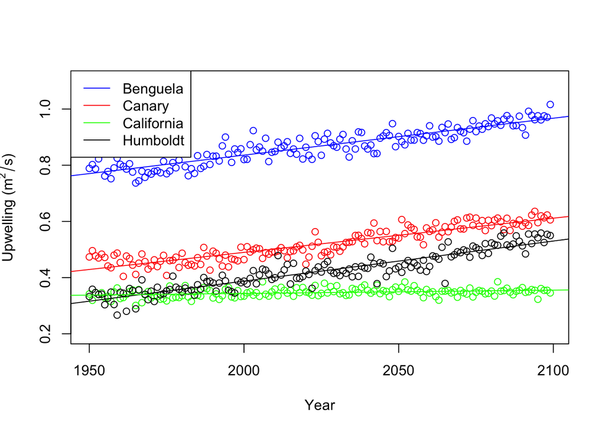

```r
par(mfrow = c(1, 1))
plot(upwelling ~ year, data = benguela.mean, ylim = c(0.2, 1.1), ylab = expression(paste("Upwelling (",
  m^2/s, ")")), xlab = "Year", col = "blue")
points(upwelling ~ year, data = canary.mean, col = "red")
points(upwelling ~ year, data = california.mean, col = "green")
points(upwelling ~ year, data = humboldt.mean, col = "black")
# Add trend lines from your analysis. Insert the model
# name into the XXXX fields
abline(humboldt.lm, col = "black")
abline(canary.lm, col = "red")
abline(benguela.lm, col = "blue")
abline(california.lm, col = "green")
legend(x = "topleft", lty = 1, col = c("blue", "red", "green",
  "black"), legend = c("Benguela", "Canary", "California",
  "Humboldt"))
```